# (Multivariate) Gaussian Distribution

[figure not shown]

# Introduction

The Gaussian distribution, also known as the normal distribution, is the most extensively utilized probability distribution for real-valued random variables . In this article, we will delve into the definition of the (multivariate) Gaussian distribution and elucidate why it assumes its particular form through the *principle of maximum entropy*. Additionally, we will derive the normalization constant in the Gaussian probability density function (PDF).

# Univariate Gaussian distribution

## Normalizing constant

In order for one function to be a valid PDF, it has to integrate 1. Concretely, in the case of the Standard Normal PDF, we have to find a constant such that:

So we need to come up with another clever way to deal with this integral instead of solving it directly. We can start by writing it twice:

For the sake of convenience, we can rewrite (1) as follows:

Now comes the "*pulling the rabbit out of the hat*" moment, where we'll transform (2) into [Polar ordinate](https://en.wikipedia.org/wiki/Polar_coordinate_system#:~:text=In%20mathematics%2C%20the%20polar%20coordinate,angle%20from%20a%20reference%20direction.) instead of [Cartesian coordinate](https://en.wikipedia.org/wiki/Cartesian_coordinate_system).

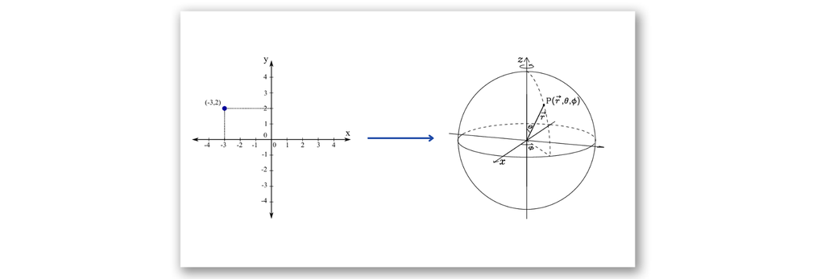

This is known as Change of variables (please refer to [Harvard Stat110's Math Handout](https://projects.iq.harvard.edu/sites/projects.iq.harvard.edu/files/stat110/files/math_review_handout.pdf) as a quick reference). We can thus write the following:

Remark.

# Gaussian distribution derivation from Principle of Maximum entropy

Definition.

For a continuous random variable with a probability density function , the entropy is defined as:

Maximum entropy pdf with fixed mean and variance

Taking the derivative of w.r.t. , we obtain:

We now have to make sure that the above form of satisfies the initial constraints. In particular:

and

which is exactly the form of the PDF of the Gaussian distribution.

# Multivariate Gaussian distribution

## Definition

Similar to the univariate Gaussian distribution, the Multivariate Gaussian distribution also has two parameters, the vector mean and the covariance matrix . The mean is a vector that describes the position of the distribution, and the covariance matrix is a symmetric positive definite matrix that describes the shape of the distribution.

Definition (The Multivariate Gaussian distribution).

A vector-valued random variable is said to have a multivariate normal (or Gaussian) distribution with mean and covariance matrix if its probability density function is given by:

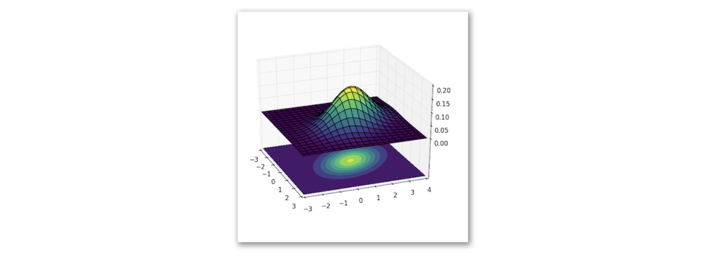

## Types of Covariance Matrix

There are three forms of the covariance matrix in multivariate normals, including *spherical*, *diagonal*, and *full* covariances. For the bivariate (two dimensional) case, these are:

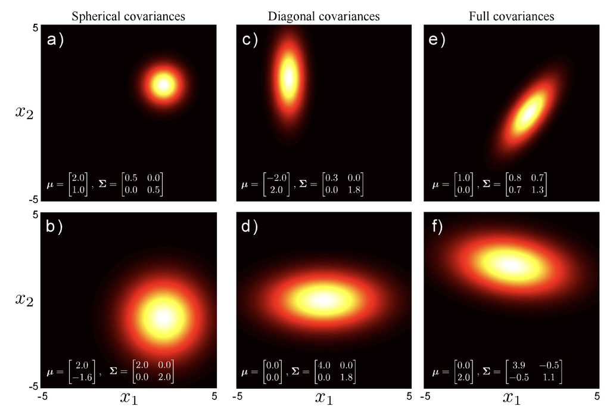

# References

- [Stanford CS109's course reader](https://chrispiech.github.io/probabilityForComputerScientists/en/part2/normal/)
- [Stanford CS229 handout](https://cs229.stanford.edu/section/gaussians.pdf)
- https://michael-franke.github.io/intro-data-analysis/the-maximum-entropy-principle.html